# V506 Lab 3

Pipes and ggplot

Luis Navarro

Fall 2024

# Online R Resources

- [R Cookbook](https://rc2e.com/)
- [Introduction to Data Exploration with R](https://bookdown.org/mikemahoney218/IDEAR/)
- [R for Data Science](https://r4ds.had.co.nz/)
- [R Markdown: The Definitive Guide](https://bookdown.org/yihui/rmarkdown/)
- [ggplot2: Elegant Graphics for Data Analysis](https://ggplot2-book.org/)
- [Introduction to Econometrics with R](https://www.econometrics-with-r.org/)
- Check more [here](https://www.rstudio.com/resources/books/)

# Pipeline for today

- Programming Basics (Conditional Operators)
- Pipes
- ggplot

# Clean Environment Question

- To remove specific objects from the environment you can use the `rm` function.
- We covered that the following code removes all objects stored in the environment.

```r
rm(list = ls())
```

- Let’s say you want to only erase a some objects from your environment.

```r
# Define objects
temp1 <- 1:10
temp2 <- 11:20
temp3 <- 21:30
# Erase object temp1
rm(temp1)
# Erase objects temp2 and temp3
rm(list = c("temp2", "temp3"))
```

# Install Packages for Today

- Let’s install all the packages we will be using today.
- *Tip* notice we can write the statement in one line of code.

```r
if(!require(pacman)) {install.packages("pacman")}
if(!require(rmarkdown)) {install.packages("rmarkdown")}
if(!require(here)) {install.packages("here")}
if(!require(dplyr)) {install.packages("dplyr")}
if(!require(ggplot2)) {install.packages("ggplot2")}
if(!require(gridExtra)) {install.packages("gridExtra")}
```

- Let’s use *p_load* to load all the packages we will be using into the environment.

```r
library(pacman)
p_load(rmarkdown,dplyr,ggplot2,gridExtra,here)
```

# Programming Basics

- Logical expressions (also called Boolean expressions) are the result of applying logical operators to relational or arithmetic expressions.
- The result of an operation has two possible states: true or false.
- You can think them as questions or conditions. Ex. Is $a > b$?
- Programming tip: using these expressions we can tell the computer to execute a specific task when certain conditions are met.
- There are several logical operators.

```r
> # greater than
< # less than
>= # greater than or equal to
<= # less than or equal to
== # exactly equal to
!= # not equal to
!  # not
|  # or
&  # and
```

# Logical Expressions and Logical Operators

```r
# Define a and b
x = 5
y = 10

# Logical Expressions.
# is x greater than y ?
x>y
# is x greater or equal than y ?
x>=y
# is x less or equal than y ?
x<=y
# is x equal to y ?
x==y
# is x not equal to y ?
x!=y
```

- **Note:** They can be applied to vectors too (and other objects as well!).

```r
# Define a sequence of numbers from 1 to 15
seq <- c(1:15)
# Create an array with TRUE or FALSE, depending on the result of the logical test
great15 <- seq>=5
# Explore it
print(great15)
```

```
##  [1] FALSE FALSE FALSE FALSE  TRUE  TRUE  TRUE  TRUE  TRUE  TRUE  TRUE  TRUE
## [13]  TRUE  TRUE  TRUE
```

```r
summary(great15)
```

```
##    Mode   FALSE    TRUE
## logical       4      11
```

# Conditional Statements

- Conditional statements or expressions tell the computer to execute certain actions, provided certain conditions are met.
- The code is executed if and only if the pre-stated conditions are either true or false, depending on the functions the programmer has in mind.
- Syntax *if* and between parentheses the conditional statement. In between brackets you write the action to be done.
- Example: if $x>y$ then print *apples are better than bananas*

```r
if(x>y){
  print("Apples are better than Bananas")
}
```

# Conditional Operators: ifelse()

- ifelse() is a conditional operator.
- The usage is:

```r
ifelse(test, yes, no)
```

- In the first part of the argument, you enter the test (logical or conditional expression) which will should have a logical outcome (TRUE or FALSE)
- “yes” returns the value for the true elements of the test
- “no” returns the value for the false elements of the test.
- Example. For numbers between 5 and 10, return 1, and 0 otherwise.

```r
seq <- c(1:15)
print(seq)
```

```
##  [1]  1  2  3  4  5  6  7  8  9 10 11 12 13 14 15
```

```r
# Conditional Operator
test <- seq>= 5  & seq <=10
ifelse(test,1,0)
```

```
##  [1] 0 0 0 0 1 1 1 1 1 1 0 0 0 0 0
```

# Pipes: Background

- Pipes are a powerful tool for clearly expressing a sequence of multiple operations.
- Pipe = *%>%* comes from the **magrittr** package (part of tidyverse).
- To insert a pipe into your code:

– For Windows: Ctrl + Shift + M

– For Mac: Cmd + Shift + M

- Remember R is object oriented. You are regularly applying functions to objects. Pipes provide a simple way to instrument this operation and make the code to read better.
- *Benefit:* Pipes allow to write and visualize code as an ordered list of steps. Best practice.

# Pipes: Math Intution

*Pipes* are operators to indicate we are applying a function to an object.

- Example: Define $y$ as a function $f$ of $x$.
- $y = f(x)$

*Pipes* allow us to write this in a different way. $y$ is equal to $x$ after applying $f$ to it.

- $y = x$ *%>%* $f$
- Example with code: function composition.
- Let $y = t(x)$ and $z = h(y)$ where $f$ and $h$ are two different functions.
- To compute $z$ I first apply $f$ to $x$ and then I apply $h$ to the output of that operation.
- $z = h(t(x))$
- Let $t$ be the *tibble* function and $h$ the *head* function. Hence, $z$ shows the top part of a tibble object.
- Intuition: you are applying functions in ordered layers.

```r
# Define a data frame x
a = c(1:50)
b = c(101:150)
x <- data.frame(v1=a,v2=b,v3=a>3, v4=b<103)
```

- *Standard Approach*

```r
y <- tibble(x)
z <- head(y)
z
```

```
## # A tibble: 6 × 4
##      v1    v2 v3    v4
##   <int> <int> <lgl> <lgl>
## 1     1   101 FALSE TRUE
## 2     2   102 FALSE TRUE
## 3     3   103 FALSE FALSE
## 4     4   104 TRUE  FALSE
## 5     5   105 TRUE  FALSE
## 6     6   106 TRUE  FALSE
```

- *With Pipes* we can write the functions as an ordered list. First a convert to tibble, then apply head function.

_ Tip: use vertical spaces to write your code as a list. Each additional step is applied to the object resulting from the previous operation.

```r
z <- x %>%
  tibble() %>%
  head()
z
```

```
## # A tibble: 6 × 4
##      v1    v2 v3    v4
##   <int> <int> <lgl> <lgl>
## 1     1   101 FALSE TRUE
## 2     2   102 FALSE TRUE
## 3     3   103 FALSE FALSE
## 4     4   104 TRUE  FALSE
## 5     5   105 TRUE  FALSE
## 6     6   106 TRUE  FALSE
```

# Examples: Pipes in Dplyr

Load the Star Wars data set available at the dplyr library. It contains characteristics on Star Wars characters.

- *Tip:* you can write the name of the library followed by `::` to access objects (e.g. functions, data sets) from such library.

```r
starwars <- dplyr::starwars
```

Explore it.

```r
starwars %>%
  glimpse()
```

```
## Rows: 87
## Columns: 14
## $ name       <chr> "Luke Skywalker", "C-3PO", "R2-D2", "Darth Vader", "Leia Or…
## $ height     <int> 172, 167, 96, 202, 150, 178, 165, 97, 183, 182, 188, 180, 2…
## $ mass       <dbl> 77.0, 75.0, 32.0, 136.0, 49.0, 120.0, 75.0, 32.0, 84.0, 77.…
## $ hair_color <chr> "blond", NA, NA, "none", "brown", "brown, grey", "brown", N…
## $ skin_color <chr> "fair", "gold", "white, blue", "white", "light", "light", "…
## $ eye_color  <chr> "blue", "yellow", "red", "yellow", "brown", "blue", "blue",…
## $ birth_year <dbl> 19.0, 112.0, 33.0, 41.9, 19.0, 52.0, 47.0, NA, 24.0, 57.0, …
## $ sex        <chr> "male", "none", "none", "male", "female", "male", "female",…
## $ gender     <chr> "masculine", "masculine", "masculine", "masculine", "femini…
## $ homeworld  <chr> "Tatooine", "Tatooine", "Naboo", "Tatooine", "Alderaan", "T…
## $ species    <chr> "Human", "Droid", "Droid", "Human", "Human", "Human", "Huma…
## $ films      <list> <"A New Hope", "The Empire Strikes Back", "Return of the J…
## $ vehicles   <list> <"Snowspeeder", "Imperial Speeder Bike">, <>, <>, <>, "Imp…
## $ starships  <list> <"X-wing", "Imperial shuttle">, <>, <>, "TIE Advanced x1",…
```

Define a data frame that only contains all the female characters.

- Hint: the arrange function allows you to sort the data. Read its documentation.

```r
# Filter only female characters
sw_female <- starwars %>%
  filter(sex=="female")
# Show the top 10 rows of the data set and order it by home world.
sw_female %>%  arrange(by_group = homeworld) %>%
  head(n = 10L)
```

```
## # A tibble: 10 × 14
##    name     height  mass hair_color skin_color eye_color birth_year sex   gender
##    <chr>     <int> <dbl> <chr>      <chr>      <chr>          <dbl> <chr> <chr>
##  1 Leia Or…    150  49   brown      light      brown             19 fema… femin…
##  2 Mon Mot…    150  NA   auburn     fair       blue              48 fema… femin…
##  3 Adi Gal…    184  50   none       dark       blue              NA fema… femin…
##  4 Jocasta…    167  NA   white      fair       blue              NA fema… femin…
##  5 Taun We     213  NA   none       grey       black             NA fema… femin…
##  6 Luminar…    170  56.2 black      yellow     blue              58 fema… femin…
##  7 Barriss…    166  50   black      yellow     blue              40 fema… femin…
##  8 Padmé A…    185  45   brown      light      brown             46 fema… femin…
##  9 Dormé       165  NA   brown      light      brown             NA fema… femin…
## 10 Ayla Se…    178  55   none       blue       hazel             48 fema… femin…
## # ℹ 5 more variables: homeworld <chr>, species <chr>, films <list>,
## #   vehicles <list>, starships <list>
```

- We can write multiple operations in one line of code.
- Question: what is this code doing?

```r
starwars %>% filter(height > 150) %>%
             select(name, height, mass, homeworld) %>%
             arrange(by_group = name) %>%
             arrange(by_group = homeworld) %>%
             head(n=10L)
```

```
## # A tibble: 10 × 4
##    name                height  mass homeworld
##    <chr>                <int> <dbl> <chr>
##  1 Bail Prestor Organa    191    NA Alderaan
##  2 Raymus Antilles        188    79 Alderaan
##  3 Lobot                  175    79 Bespin
##  4 Jek Tono Porkins       180   110 Bestine IV
##  5 Nute Gunray            191    90 Cato Neimoidia
##  6 Ki-Adi-Mundi           198    82 Cerea
##  7 Mas Amedda             196    NA Champala
##  8 Jango Fett             183    79 Concord Dawn
##  9 Han Solo               180    80 Corellia
## 10 Wedge Antilles         170    77 Corellia
```

# Pipes and Mutate

- Pipes provide a nice syntax to create new variables.
- Example: create a dummy variable equal to one for female characters.

```r
starwars <- starwars %>%
            mutate(female = ifelse(sex == "female",1,0))
```

- Let’s look at the relevant variables

```r
starwars %>%
  select(name, sex, female) %>%
  arrange(by_group = name) %>%
  head(n=6L)
```

```
## # A tibble: 6 × 3
##   name             sex    female
##   <chr>            <chr>   <dbl>
## 1 Ackbar           male        0
## 2 Adi Gallia       female      1
## 3 Anakin Skywalker male        0
## 4 Arvel Crynyd     male        0
## 5 Ayla Secura      female      1
## 6 BB8              none        0
```

- We can keep creating variables using pipes.

```r
starwars <- starwars %>%
            mutate(height160 = ifelse(height > 160, 1,0)) %>%
            mutate(mass_height160int = mass*height160)

# Show the new variables
starwars %>% select(name,homeworld,mass, height,
                    height160, mass_height160int) %>%
             head(n=10L)
```

```
## # A tibble: 10 × 6
##    name               homeworld  mass height height160 mass_height160int
##    <chr>              <chr>     <dbl>  <int>     <dbl>             <dbl>
##  1 Luke Skywalker     Tatooine     77    172         1                77
##  2 C-3PO              Tatooine     75    167         1                75
##  3 R2-D2              Naboo        32     96         0                 0
##  4 Darth Vader        Tatooine    136    202         1               136
##  5 Leia Organa        Alderaan     49    150         0                 0
##  6 Owen Lars          Tatooine    120    178         1               120
##  7 Beru Whitesun Lars Tatooine     75    165         1                75
##  8 R5-D4              Tatooine     32     97         0                 0
##  9 Biggs Darklighter  Tatooine     84    183         1                84
## 10 Obi-Wan Kenobi     Stewjon      77    182         1                77
```

# ggplot

- ggplot is perhaps the most famous R graphing package. Also part of tidyverse.
- ggplot is based on the “grammar of graphics” which is the idea that you can build every graph from the same components: data, coordinate system, and geoms (the visual marks that represent the data/the type of graph)
- ggplot() is the function that initializes the ggplot object. It can be used to specify the data frame or the aesthetics.
- Every ggplot2 plot has three key components:

  –A data frame,

# Plots of one variable

- Let’s load the *mpg* data set which includes information about the fuel economy of popular car models in 1999 and 2008, collected by the US EPA. You can access the data by loading ggplot2.

```r
mpg <- ggplot2::mpg %>% tibble()
mpg %>% glimpse()
```

```
## Rows: 234
## Columns: 11
## $ manufacturer <chr> "audi", "audi", "audi", "audi", "audi", "audi", "audi", "…
## $ model        <chr> "a4", "a4", "a4", "a4", "a4", "a4", "a4", "a4 quattro", "…
## $ displ        <dbl> 1.8, 1.8, 2.0, 2.0, 2.8, 2.8, 3.1, 1.8, 1.8, 2.0, 2.0, 2.…
## $ year         <int> 1999, 1999, 2008, 2008, 1999, 1999, 2008, 1999, 1999, 200…
## $ cyl          <int> 4, 4, 4, 4, 6, 6, 6, 4, 4, 4, 4, 6, 6, 6, 6, 6, 6, 8, 8, …
## $ trans        <chr> "auto(l5)", "manual(m5)", "manual(m6)", "auto(av)", "auto…
## $ drv          <chr> "f", "f", "f", "f", "f", "f", "f", "4", "4", "4", "4", "4…
## $ cty          <int> 18, 21, 20, 21, 16, 18, 18, 18, 16, 20, 19, 15, 17, 17, 1…
## $ hwy          <int> 29, 29, 31, 30, 26, 26, 27, 26, 25, 28, 27, 25, 25, 25, 2…
## $ fl           <chr> "p", "p", "p", "p", "p", "p", "p", "p", "p", "p", "p", "p…
## $ class        <chr> "compact", "compact", "compact", "compact", "compact", "c…
```

- Let’s begin with graphs of one variable. Ex. Histogram.
- At least 3 elements: i) data, ii) aesthetic mapping, iii) geom with type of graph.
- The data contains the tibble with the variables to be graphed.
- The aesthetic mapping creates the space to show the graph.

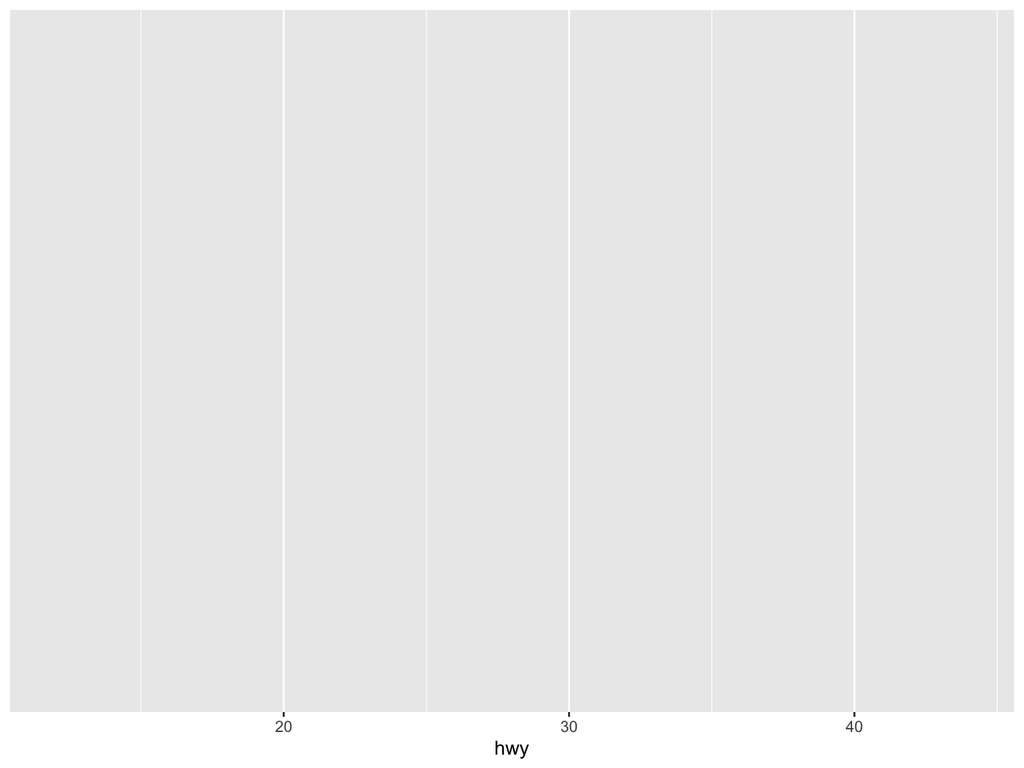

```r
# Variable notes:
# hwy: highway miles per gallon
# manufacturer: manufacturer name
ggplot(data = mpg, mapping = aes(x = hwy))
```

- The geom object specifies the way to visualize the data (i.e. the type of plot you want to create).
- *Note:* to add elements to the graph you need to use the plus `+` operator. You `add` layers to the graph.
- Example: Histogram of the distribution of the variable `highway miles per gallon`

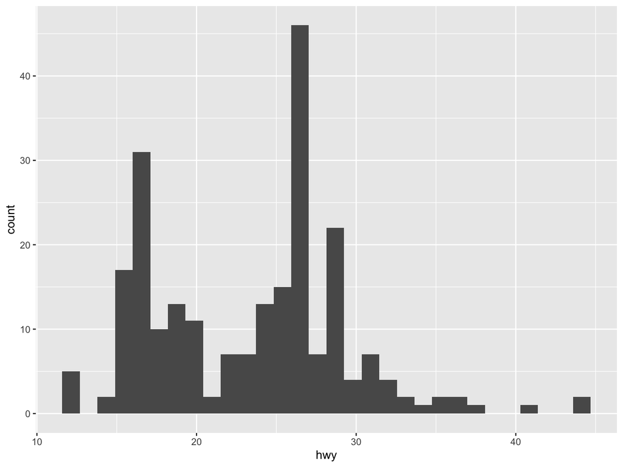

```r
ggplot(data = mpg, mapping = aes(x = hwy)) +
      geom_histogram()
```

- Tip: Assign names to the graphs.
- Explore all the available options to customize your graph.
- Add parameters to geom_histogram.
- Labs allow to write the labels. Also, you can choose from different themes.

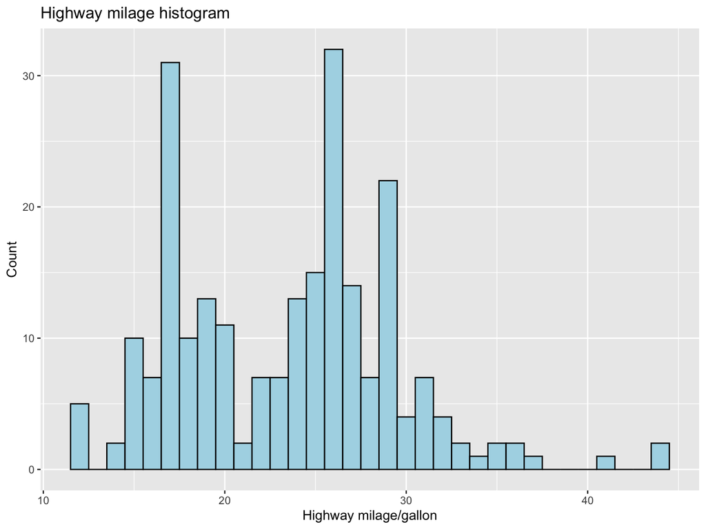

```r
hwy_histogram <- ggplot(mpg, aes(x = hwy)) +
                 geom_histogram(binwidth = 1, color = "black", fill = "lightblue" ) +
                 labs(x = "Highway milage/gallon", y = "Count", title = "Highway milage histogram")
hwy_histogram
```

- We can add layers to already defined graphs to create more complex (and cool) figures!

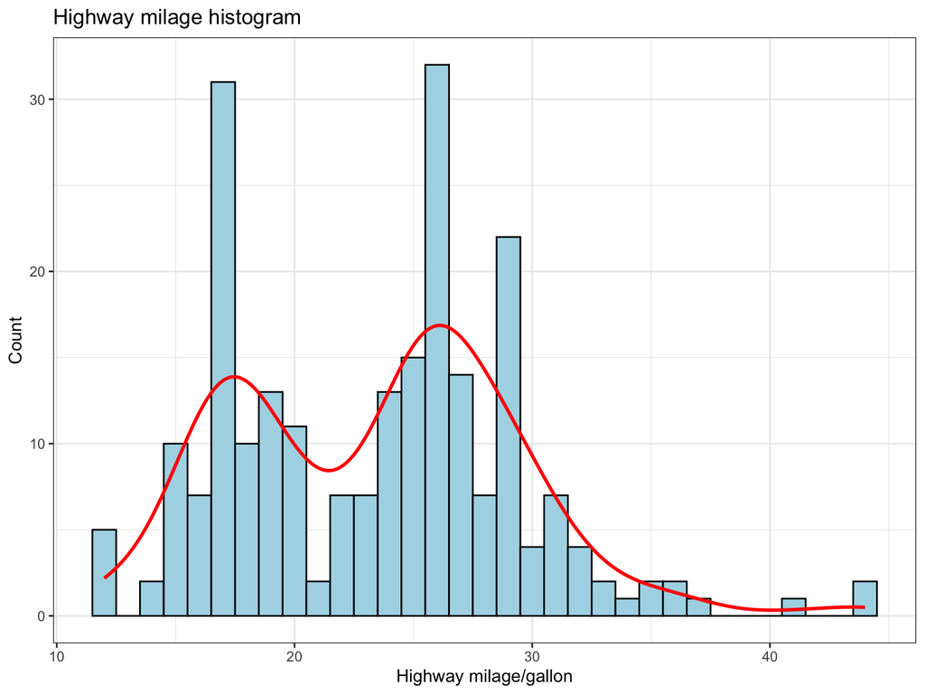

```r
hwy_histogram_improved <- hwy_histogram +
                          theme_bw() +
                          geom_density(aes(y = ..count..), color = "red", size = 1)
hwy_histogram_improved
```

- Let’s do a boxplot of the city milage/gallon variable.

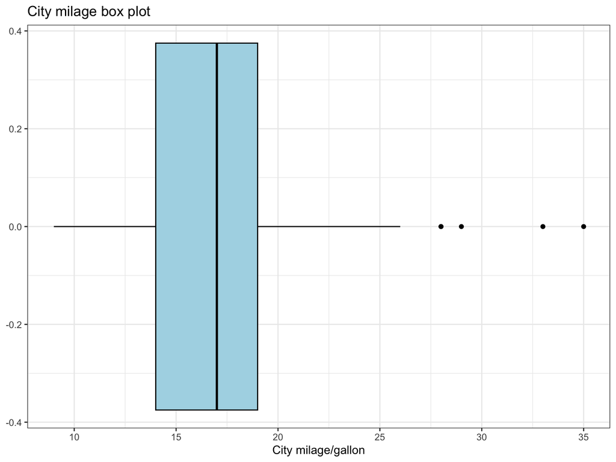

```r
cty_box <- ggplot(mpg, aes(x = cty)) +
                 geom_boxplot(color = "black", fill = "lightblue" ) +
                 theme_bw() +
                labs(x = "City milage/gallon", title = "City milage box plot")
cty_box
```

# Combining plots and exporting plots.

- **Combining Plots** We can combine plots using the *gridExtra* library (be sure to install it and load it first)
- **Exporting Plots:** use *ggsave* to export a ggplot object. You can choose the export format by changing the file extension (png, jpg, pdf).

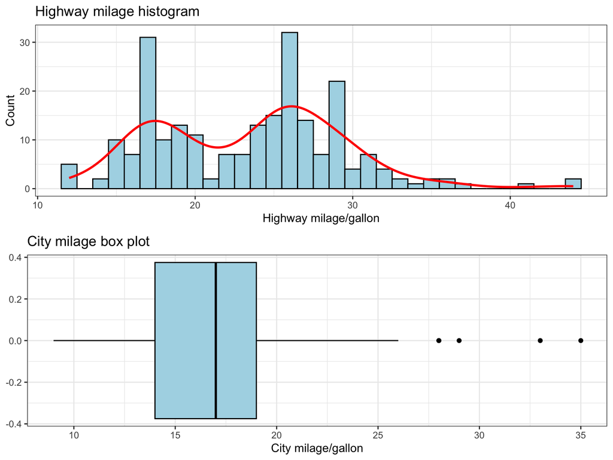

```r
# Where to store the graph
v506_path <- here("/Users/luisenriquenavarro/Library/CloudStorage/OneDrive-IndianaUniversity/V506/Fall24")
file <- here(v506_path, 'Lab3','combinedplot.jpg')
# Save the graph
graph_combined <- grid.arrange(hwy_histogram_improved,cty_box, nrow =2, ncol = 1)
```

```r
ggsave(filename = file, plot = graph_combined)
```

# Plots of two variables

- We can create graphs using aesthetic mappings of two variables.
- Example: scatter plots. Aesthetic mappings identify the $x$ and $y$ variables.

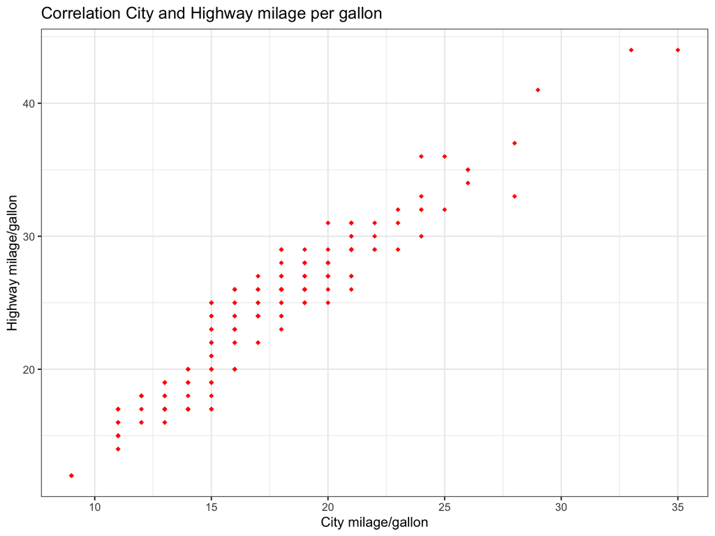

```r
scatter_hc <- ggplot(data = mpg, aes(x = cty, y = hwy)) +
              geom_point(color = "red", shape = 18) +
              labs(x = "City milage/gallon", y = "Highway milage/gallon", title = "Correlation City and Highway milage per gallon") +
              theme_bw()
scatter_hc
```

- **Creating Graphs by Categories** you can create the same graph for different categories in your data set.
- Let’s replicate the previous graph for each *class* of vehicles.

```r
mpg$class %>% factor() %>% summary()
```

```
##    2seater    compact    midsize    minivan     pickup subcompact        suv
##          5         47         41         11         33         35         62
```

- *facet_wrap* shows individual graphs for each category.

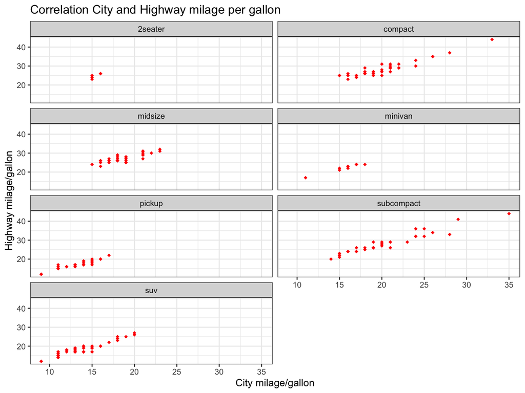

```r
scatter_hc_class1 <- scatter_hc + facet_wrap(~ class, nrow=4)
scatter_hc_class1
```

- Alternatively, you can specify a color-coding when defining the aesthetic mapping.

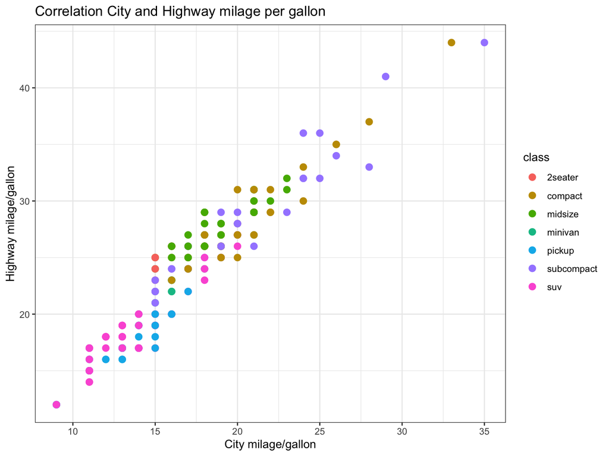

```r
scatter_hc_class2 <- ggplot(data = mpg, mapping = aes(x = cty, y = hwy, colour = class)) +
                    geom_point(shape = 16, size = 3) +
                    labs(x = "City milage/gallon", y = "Highway milage/gallon", title = "Correlation City and Highway milage per gallon") +
                    theme_bw()
scatter_hc_class2
```